# Map overlapping shapefiles

Satya Golla and Steve Simon

Created 2022-03-11

This program will compare various shapefiles for counties, public use microdata areas, census tracts, census block groups, census blocks, zip code tabulation areas, community districts, and neighborhoods. It will produce a map showing overlaps of different shapefiles. In addition, the program will compute the area of each shapefile and what percentage of that area lies inside or outside another shapefile.

### General information

The starting point for downloading most Census shapefiles is [here](https://www.census.gov/geographies/mapping-files/time-series/geo/tiger-line-file.html). The ftp site is a bit more difficult to navigate, but leads you directly to the files that you want.

It helps to know the FIPS (Federal Information Processing System) codes for Kansas (20) and Missouri (29).

The important counties for this program are

Cass County, MO (29037) Clay County, MO (29047) Jackson County, MO (29095) Johnson County, KS (20091) Leavenworth County, KS (20103) Platte County, MO (29165) Wyandotte County, KS (20209)

The community district and neighborhood shapefiles are documented in an email from Neal Wilson dated 2022-03-03. You can find a pdf file of that email in the doc folder.

### Load relevant files

```r
library(sf)
library(tidyverse)
library(magrittr)
path_name <- "../data/"
```

```r
map_overlap <- function(shape1, shape2) {
  sb <- st_intersects(shape1, shape2, sparse=FALSE)

  shape2                              %>%
    filter(as.vector(sb))              -> shape2_sb

  names <- paste0(c(shape1$label, shape2_sb$label), collapse=", ")
  shape2_in <- st_intersection(shape1, shape2_sb)

  shape1                                %>%
    st_area                             %>%
    divide_by(1e6)                      %>%
    as.numeric                           -> a1

  shape2_sb                             %>%
    st_area                             %>%
    divide_by(1e6)                      %>%
    as.numeric                           -> a2

  shape2_in                             %>%
    st_area                             %>%
    divide_by(1e6)                      %>%
    as.numeric                           -> a2_in

  shape2_sb$label                       %>%
    data.frame                          %>%
    mutate(area1=round(a1, 2))          %>%
    mutate(area2=round(a2, 2))          %>%
    mutate(area2_in=round(a2_in, 2))    %>%
    mutate(pct1=round(100*a2_in/a1, 2)) %>%
    mutate(pct2=round(100*a2_in/a2, 2)) %>%
    print

  fill_color <- case_when(
    a2_in/a2 > 0.99~"pink",
    a2_in/a2 < 0.01~"lightgreen",
    TRUE~"lightblue")
  shape2_sb %>%
    ggplot(aes())                        +
    geom_sf(fill=fill_color, col="darkgreen")    +
    ggtitle(names)                       +
    geom_sf(
      data=shape1,
      fill=NA,
      size=1.2,
      col="darkred")
}
```

### Intersect counties with community districts

```
##           . area1   area2 area2_in  pct1 pct2
## 1 Wyandotte 16.89  404.20     0.00  0.00 0.00
## 2   Jackson 16.89 1594.99    16.84 99.68 1.06
## 3      Clay 16.89 1057.50     0.05  0.32 0.01
```

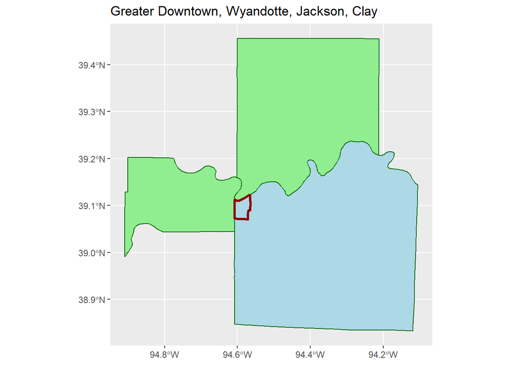

```r
load(paste0(path_name, "co", ".RData"))
load(paste0(path_name, "cd", ".RData"))
n <- 1:dim(cd)[1]
n <- 3
for (i in n) {
  map_overlap(cd[i, ], county) %>% print
}
```

### Intersect neighborhoods with community districts

```
## st_as_s2(): dropping Z and/or M coordinate
```

```
## st_as_s2(): dropping Z and/or M coordinate
```

```
##                                  . area1 area2 area2_in  pct1   pct2
## 1                         Area 241 16.89  0.33     0.33  1.97  99.90
## 2                 Downtown Airport 16.89  5.34     0.00  0.01   0.04
## 3                Coleman Highlands 16.89  0.66     0.00  0.00   0.00
## 4                    Columbus Park 16.89  0.59     0.59  3.47  99.73
## 5                   Westside North 16.89  1.26     1.26  7.49 100.00
## 6                    Hospital Hill 16.89  1.22     1.22  7.20  99.98
## 7                           Harlem 16.89  1.25     0.00  0.01   0.16
## 8                           Volker 16.89  1.45     0.00  0.00   0.00
## 9                   Westside South 16.89  1.53     1.53  9.04  99.99
## 10        Columbus Park Industrial 16.89  1.03     1.03  6.12  99.97
## 11                       Valentine 16.89  0.63     0.00  0.00   0.00
## 12                    Quality Hill 16.89  0.50     0.50  2.97 100.00
## 13                      Longfellow 16.89  0.79     0.79  4.65  99.99
## 14                    Crown Center 16.89  1.51     1.51  8.97 100.00
## 15                Broadway Gillham 16.89  0.73     0.00  0.00   0.01
## 16                    River Market 16.89  0.90     0.90  5.35 100.00
## 17                      Crossroads 16.89  0.76     0.76  4.52 100.00
## 18                    Cbd Downtown 16.89  1.60     1.60  9.49 100.00
## 19                      Union Hill 16.89  0.44     0.44  2.62  99.98
## 20                 North Hyde Park 16.89  0.57     0.00  0.00   0.02
## 21                      Paseo West 16.89  0.83     0.83  4.91  99.89
## 22               Pendleton Heights 16.89  1.69     0.11  0.64   6.41
## 23                     Center City 16.89  0.32     0.00  0.00   0.00
## 24 18th And Vine And Downtown East 16.89  1.06     0.00  0.00   0.00
## 25                    Beacon Hills 16.89  0.93     0.00  0.00   0.01
## 26                        Parkview 16.89  0.53     0.00  0.00   0.02
## 27                Wendell Phillips 16.89  1.76     0.00  0.00   0.02
## 28   Northeast Industrial District 16.89  6.94     0.00  0.01   0.01
## 29                    West Bottoms 16.89  3.47     3.47 20.55  99.91
```

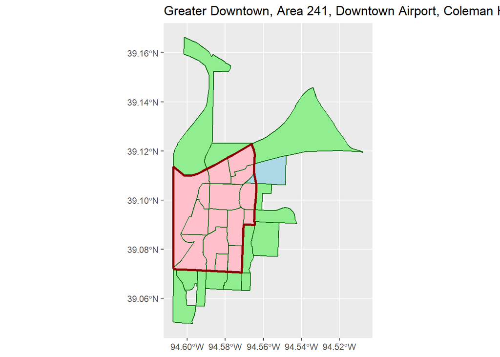

```r
load(paste0(path_name, "nbd", ".RData"))
n <- 1:dim(cd)[1]
n <- 3
for (i in n) {
  map_overlap(cd[i, ], nbd) %>% print
}
```

### Intersect community districts with census blocks

```
##                    . area1 area2 area2_in pct1   pct2
## 1    290950023002014 26.15  0.01     0.01 0.06 100.00
## 2    290950063002017 26.15  0.01     0.01 0.04 100.00
## 3    290950022003001 26.15  0.02     0.02 0.07 100.00
## 4    290950022003004 26.15  0.02     0.02 0.07 100.00
## 5    290950022003005 26.15  0.02     0.02 0.07 100.00
## 6    290950022003003 26.15  0.02     0.02 0.07 100.00
## 7    290950022003007 26.15  0.03     0.03 0.13  99.69
## 8    290950022001018 26.15  0.04     0.00 0.00   0.13
## 9    290950022002003 26.15  0.00     0.00 0.00   0.29
## 10   290950160002006 26.15  0.02     0.02 0.06 100.00
## 11   290950160002004 26.15  0.01     0.01 0.05 100.00
## 12   290950023002012 26.15  0.02     0.02 0.06 100.00
## 13   290950023002013 26.15  0.01     0.01 0.06 100.00
## 14   290950160002003 26.15  0.01     0.01 0.05 100.00
```

[output cut: 1243 more lines]

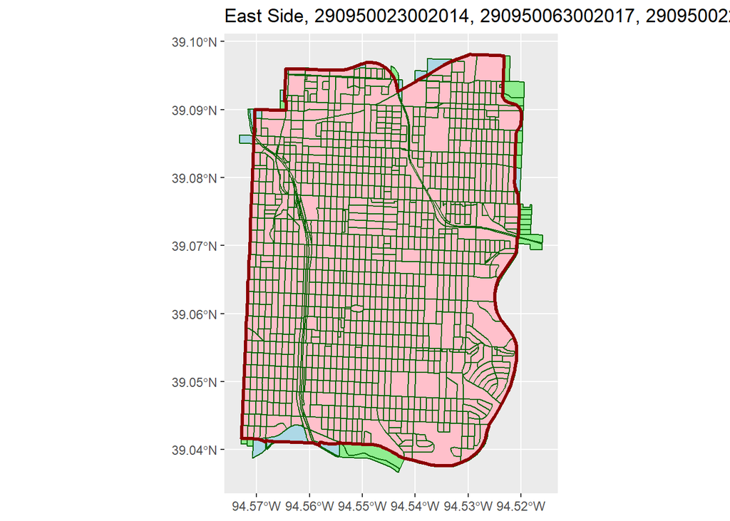

```
##                   . area1 area2 area2_in pct1   pct2
## 1   290950006001006 10.98  0.02     0.02 0.20 100.00
## 2   290950006003010 10.98  0.00     0.00 0.04 100.00
## 3   290950006003011 10.98  0.02     0.02 0.19 100.00
## 4   290950006003012 10.98  0.02     0.02 0.19 100.00
## 5   290950006003004 10.98  0.02     0.02 0.18 100.00
## 6   290950006003014 10.98  0.02     0.02 0.17 100.00
## 7   290950155001122 10.98  0.02     0.00 0.00   1.86
## 8   290950019001018 10.98  0.02     0.02 0.18 100.00
## 9   290950019001009 10.98  0.02     0.02 0.18 100.00
## 10  290950019001019 10.98  0.02     0.02 0.19 100.00
## 11  290950006004012 10.98  0.02     0.02 0.18 100.00
## 12  290950006002006 10.98  0.02     0.02 0.19 100.00
## 13  290950006002015 10.98  0.02     0.02 0.18 100.00
## 14  290950006004014 10.98  0.02     0.02 0.18 100.00
```

[output cut: 550 more lines]

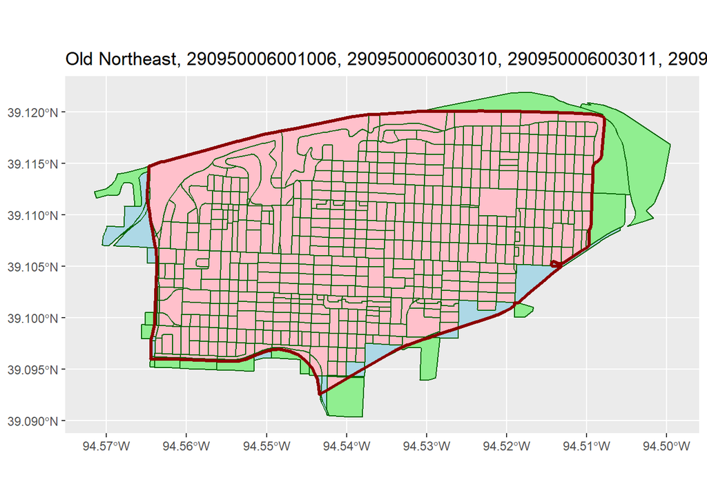

```
##                   . area1 area2 area2_in pct1   pct2
## 1   202099805001020 16.89  0.04     0.00 0.00   0.00
## 2   202090430004001 16.89  0.45     0.00 0.00   0.02
## 3   290470221006171 16.89  1.13     0.05 0.31   4.58
## 4   290470221006080 16.89  0.01     0.00 0.00  10.95
## 5   290470221006166 16.89  0.10     0.00 0.01   1.14
## 6   290470221006079 16.89  0.07     0.00 0.00   0.19
## 7   290950043002001 16.89  0.01     0.01 0.05 100.00
## 8   290950043002002 16.89  0.01     0.01 0.08 100.00
## 9   290950167003000 16.89  0.04     0.00 0.00   0.60
## 10  290950167003001 16.89  0.02     0.00 0.00   0.38
## 11  290950161001010 16.89  0.02     0.02 0.10 100.00
## 12  290950161002046 16.89  0.02     0.02 0.09 100.00
## 13  290950161002045 16.89  0.01     0.01 0.08 100.00
## 14  290950161001009 16.89  0.02     0.02 0.10 100.00
```

[output cut: 889 more lines]

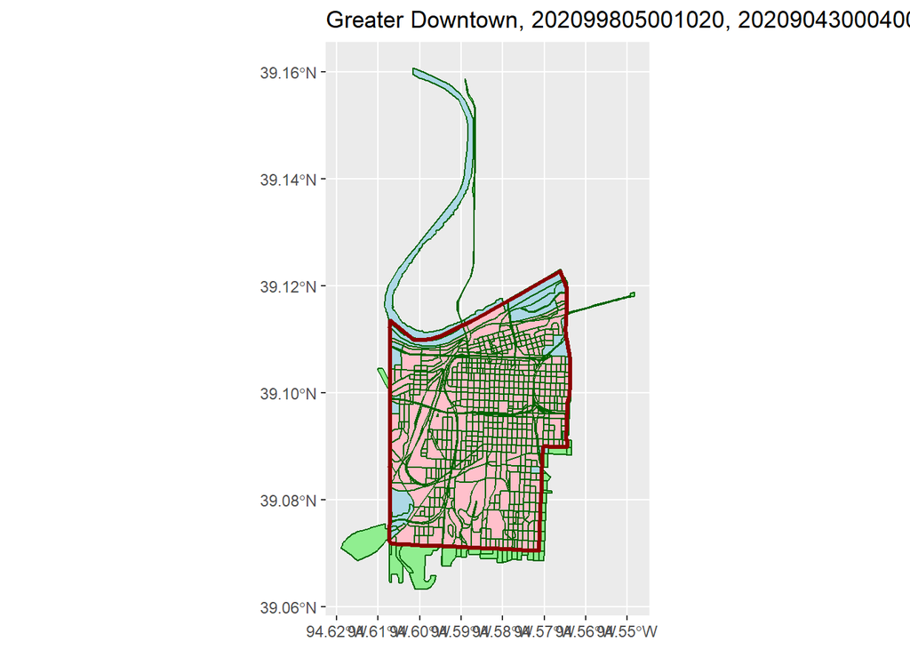

```r
load(paste0(path_name, "bl", ".RData"))
n <- 1:dim(cd)[1]
n <- 1:3
for (i in n) {
  map_overlap(cd[i, ], bl) %>% print
}
```